# Ewing polysomeSeq analysis

This document details the analysis of sequencing data from the Renata to study polysome changes in Ewing sarcoma tumours.

## Setting up the environment

These are packages you will need for this notebook. For exact versions used, please refer to the session info at the bottom of this notebook.

```r
##########################################################################################
library('tidyverse')
library('RColorBrewer')
library('ggplot2')
library('tximport')
library('GenomicFeatures')
library('DESeq2')
library('org.Hs.eg.db')
library('ggrepel')
```

I want to set a base directory that we can use as a link to the directory where we will do most of the work. I use two directories here because the Workspace is what is pushed to GitHub and contains scripts and plot files, but the Repository is where more of the big data is stored that does not get pushed.

```r
##########################################################################################
generalDatasets = 'C:/Users/chughes/Documents/bccrc/projectsRepository/generalDatasets'
baseWorkspace = 'C:/Users/chughes/Documents/bccrc/projectsWorkspace/sorensenLab/relatedToYbx1'
baseRepository = 'C:/Users/chughes/Documents/bccrc/projectsRepository/sorensenLab/relatedToYbx1'
#generalDatasets = 'C:/Users/chris/OneDrive/Documents/bccrc/projectsRepository/generalDatasets'
#baseWorkspace = 'C:/Users/chris/OneDrive/Documents/bccrc/projectsWorkspace/sorensenLab/relatedToYbx1'
#baseRepository = 'C:/Users/chris/OneDrive/Documents/bccrc/projectsRepository/sorensenLab/relatedToYbx1'
```

## Data processing

Make the samples data frame.

```r
##########################################################################################
samples = tibble('sample' = c(paste('P14057_10',seq(65,99,1),sep=''), paste('P14057_1',seq(100,102,1),sep='')),
                 'experiment' = rep(c('tot','poly'),19),
                 'treatment' = c(rep('entinostat',14), rep('control',12), rep('control',6), rep('entinostat',6)),
                 'type' = c(rep('cell',26), rep('cdx',12)))
samples$identifier = c(paste(samples$experiment,samples$type,samples$treatment,sep=''))

##
files = file.path(baseRepository, 'sequencing20210322_ewingPolysomeSeqRenata', paste(samples$sample, '_quant', sep = ''), 'quant.sf')
all(file.exists(files))
```

```
[1] TRUE
```

```r
##
myTxdb = makeTxDbFromGFF('C:/Users/chughes/Documents/bccrc/databases/hg38/gencode_gtf/2230c535660fb4774114bfa966a62f823fdb6d21acf138d4.gtf.gz')
```

```
The "phase" metadata column contains non-NA values for features of type stop_codon. This information was ignored.
```

```r
k = keys(myTxdb, keytype = 'TXNAME')
tx2gene = AnnotationDbi::select(myTxdb, k, 'GENEID', 'TXNAME')
```

Now import the data to a transcriptome object and then export the counts and abundance data to files.

```r
##########################################################################################
txi = tximport(files,
               type = 'salmon',
               tx2gene = tx2gene)
```

```
reading in files with read_tsv
1 2 3 4 5 6 7 8 9 10 11 12 13 14 15 16 17 18 19 20 21 22 23 24 25 26 27 28 29 30 31 32 33 34 35 36 37 38
transcripts missing from tx2gene: 21785
summarizing abundance
summarizing counts
summarizing length
```

```r
names(txi)
```

```
[1] "abundance"           "counts"              "length"              "countsFromAbundance"
```

```r
head(txi$counts)
```

```
                       [,1]    [,2]     [,3]     [,4]     [,5]     [,6]     [,7]     [,8]     [,9]    [,10]    [,11]    [,12]    [,13]    [,14]    [,15]    [,16]
ENSG00000000003.14 2746.331 2539.70 1792.552 1777.551 2187.679 1725.591 2661.866 1027.753 4896.416 5296.023 7408.947 4414.558 8046.596 7300.863 2980.373 1365.183
ENSG00000000005.5     0.000    0.00    0.000    0.000    0.000    0.000    1.000    0.000    0.000    0.000    0.000    0.000    0.000    0.000    0.000    0.000
ENSG00000000419.12  748.000  419.00  614.000  275.000  333.000  264.000  424.000  110.000 1345.000 1128.000 2538.000  797.000 2882.999 1609.000  713.000  203.000
ENSG00000000457.13    0.000    0.00   25.330    5.520    4.028    5.576    0.000    3.696   38.156   20.291   19.945    6.568   77.206    2.601    0.000    0.000
ENSG00000000460.16  330.272  383.09  125.363  264.199  258.872  232.406  153.267  199.641  607.222  771.100  547.271  974.530  541.065  725.231  200.632   33.118
ENSG00000000938.12    0.000   12.00    0.000    0.000    4.000    0.000   17.000    0.000    0.000    5.000   13.000    2.000    0.000    0.000    0.000    9.000
                      [,17]    [,18]    [,19]    [,20]    [,21]    [,22]    [,23]    [,24]    [,25]    [,26]    [,27]    [,28]    [,29]    [,30]    [,31]    [,32]
ENSG00000000003.14 2976.061 7329.943 4752.190 9354.757 2024.378 2071.831 5191.620 4387.236 4908.255 6086.462 2066.639 1440.829 1096.960 1521.985 1810.903 3022.078
ENSG00000000005.5     0.000    0.000    0.000    0.000    0.000    0.000    0.000    0.000    0.000    0.000    0.000    0.000    0.000    0.000    0.000    0.000
ENSG00000000419.12 1111.000 1718.000  696.000 1976.000  244.000  618.000 1137.000  716.999 1280.000  951.000 2006.000 1052.000  811.000 1650.000  795.000 2540.001
ENSG00000000457.13   61.535  120.146   39.244   65.058    9.801    6.993   44.738    0.000    0.000    6.886    5.038    0.000   45.538    0.000   10.399  231.010
ENSG00000000460.16  453.666  984.315  102.774  861.440  160.576  313.878  357.838  561.343  258.309 1018.877  742.294  385.694  353.851  407.759  223.722  604.227
ENSG00000000938.12    0.000   14.000   16.000   15.731   31.000   10.000    0.000    4.000    2.000   13.000   15.000   25.000   13.000   25.000    1.000   41.000
                      [,33]    [,34]    [,35]    [,36]    [,37]    [,38]
ENSG00000000003.14 1467.917 1440.987 1526.000 3243.988 1539.249 1530.716
ENSG00000000005.5     0.000    0.000    0.000    0.000    0.000    0.000
ENSG00000000419.12 1341.000 2103.000 1019.999 3527.000 1285.000 1339.999
ENSG00000000457.13   89.988    9.680  158.277  191.573    9.346    0.000
ENSG00000000460.16  628.527  678.072  487.896  901.817  336.290  517.847
ENSG00000000938.12   38.000   82.000   70.000  162.000   68.000   72.000
```

```r
##
txExport = as.data.frame(txi$counts)
colnames(txExport) = samples$sample
txExport$ensembl = row.names(txExport)
ens.str = substr(rownames(txExport), 1, 15)
txExport$symbol = mapIds(org.Hs.eg.db,
                     keys=ens.str,
                     column="SYMBOL",
                     keytype="ENSEMBL",
                     multiVals="first")
saveRDS(txExport[,c(39:40,1:38)],
        paste(baseRepository, '/sequencing20210322_ewingPolysomeSeqRenata/dataset_rawCountsSalmonAllData.rds', sep = ''))
write.table(txExport[,c(39:40,1:38)],
          file = paste(baseRepository, '/sequencing20210322_ewingPolysomeSeqRenata/dataset_rawCountsSalmonAllData.tsv', sep = ''),
          quote = FALSE, col.names = TRUE, row.names = FALSE, sep = '\t')

##
txExport = as.data.frame(txi$abundance)
colnames(txExport) = samples$sample
txExport$ensembl = row.names(txExport)
ens.str = substr(rownames(txExport), 1, 15)
txExport$symbol = mapIds(org.Hs.eg.db,
                     keys=ens.str,
                     column="SYMBOL",
                     keytype="ENSEMBL",
                     multiVals="first")
saveRDS(txExport[,c(39:40,1:38)],
        paste(baseRepository, '/sequencing20210322_ewingPolysomeSeqRenata/dataset_tpmSalmonAllData.rds', sep = ''))
write.table(txExport[,c(39:40,1:38)],
          file = paste(baseRepository, '/sequencing20210322_ewingPolysomeSeqRenata/dataset_tpmSalmonAllData.tsv', sep = ''),
          quote = FALSE, col.names = TRUE, row.names = FALSE, sep = '\t')
```

Now we can construct the DESeq2 dataset.

```r
##########################################################################################
ddsTxi = DESeqDataSetFromTximport(txi,
                                  colData = samples,
                                  design = ~ identifier)
```

```
some variables in design formula are characters, converting to factorsusing counts and average transcript lengths from tximport
```

```r
##
dds = DESeq(ddsTxi)
```

```
using 'avgTxLength' from assays(dds), correcting for library size
-- replacing outliers and refitting for 60 genes
-- DESeq argument 'minReplicatesForReplace' = 7
-- original counts are preserved in counts(dds)
```

```r
keep = rowSums(counts(dds)) >= 10
dds = dds[keep,]
```

Perform comparisons between samples.

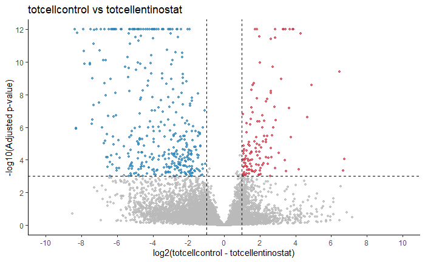

```r
##########################################################################################
datasetFirst = 'totcellcontrol'
datasetSecond = 'totcellentinostat'
res = results(dds, contrast = c('identifier', datasetFirst, datasetSecond))
ens.str = substr(rownames(res), 1, 15)
res$symbol = mapIds(org.Hs.eg.db,
                     keys=ens.str,
                     column="SYMBOL",
                     keytype="ENSEMBL",
                     multiVals="first")
resOrdered = res[order(res$pvalue),]

##
saveRDS(as.data.frame(resOrdered),
        paste(baseRepository, '/sequencing20210322_ewingPolysomeSeqRenata/dataset_deseq2_', datasetFirst, '-', datasetSecond, '.rds', sep = ''))
write.csv(as.data.frame(resOrdered),
          file = paste(baseRepository, '/sequencing20210322_ewingPolysomeSeqRenata/dataset_deseq2_', datasetFirst, '-', datasetSecond, '.csv', sep = ''))

##
#resLFC = lfcShrink(dds, coef = paste('treatment_',datasetFirst,'_vs_',datasetSecond, sep = ''), type = "apeglm")
#resLFC
#plotMA(resLFC, ylim = c(-2,2))
rnaExp = as.data.frame(resOrdered)
rnaExp$logPValue = -log10(rnaExp$padj)
rnaExp$logPValueScaled = ifelse(rnaExp$logPValue > 12, 12, rnaExp$logPValue)
rnaExp$pColors = ifelse(rnaExp$padj <= 0.001 & rnaExp$log2FoldChange >= 1, brewer.pal(8,'Spectral')[1],
                        ifelse(rnaExp$padj <= 0.001 & rnaExp$log2FoldChange <= -1, brewer.pal(8,'Spectral')[8], brewer.pal(11,'RdGy')[8]))
rnaExp$pText = ifelse(grepl('YBX1',rnaExp$symbol), rnaExp$symbol, '')
##
ggplot(rnaExp, aes(log2FoldChange, logPValueScaled)) +
  geom_point(size = 1, color = rnaExp$pColors, alpha = 0.75) +
  labs(x = paste('log2(',datasetFirst,' - ',datasetSecond,')', sep = ''), y = '-log10(Adjusted p-value)', title = paste(datasetFirst,' vs ',datasetSecond, sep='')) +
  geom_text_repel(label = rnaExp$pText, nudge_x = 2, nudge_y = -1) +
  scale_x_continuous(limits = c(-10,10), breaks = seq(-10,10,2)) +
  scale_y_continuous(limits = c(0,12), breaks = seq(0,12,2)) +
  geom_vline(xintercept = c(-1,1), linetype = 'dashed') +
  geom_hline(yintercept = -log10(0.001), linetype = 'dashed') +
  theme_classic()
##
ggsave(paste(baseRepository, '/sequencing20210322_ewingPolysomeSeqRenata/scatter_deseq2_', datasetFirst, '-', datasetSecond, '.pdf', sep = ''),
       height = 4, width = 4, useDingbats = FALSE)
```

Lets cross reference these data with some of the CLIPseq data that we have from Chen et al.

[figure not shown]

Lets compare trancriptome to translatome.

```r
##########################################################################################
poly = readRDS(paste(baseRepository, '/sequencing20210322_ewingPolysomeSeqRenata/dataset_deseq2_polycellcontrol-polycellentinostat.rds', sep = ''))
total = readRDS(paste(baseRepository, '/sequencing20210322_ewingPolysomeSeqRenata/dataset_deseq2_totcellcontrol-totcellentinostat.rds', sep = ''))

allData = total %>%
  dplyr::select(symbol, log2FoldChange) %>%
  dplyr::filter(!is.na(symbol)) %>%
  dplyr::rename(total = log2FoldChange) %>%
  left_join(poly) %>%
  dplyr::select(symbol, total, log2FoldChange) %>%
  dplyr::rename(poly = log2FoldChange)

##
allData$pColors = ifelse(allData$total > 2 & allData$poly > 2, brewer.pal(8,'Spectral')[1],
                        ifelse(allData$total < -2 & allData$poly < -2, brewer.pal(8,'Spectral')[8], brewer.pal(11,'RdGy')[8]))
ggplot(allData, aes(total, poly)) +
  geom_point(size = 1, color = allData$pColors, alpha = 0.75) +
  labs(x = 'log2(total dmso - entinostat)', y = 'log2(polysome dmso - entinostat)', title = 'Entinostat translatome') +
  #geom_text_repel(label = rnaExp$pText, nudge_x = 2, nudge_y = -1) +
  scale_x_continuous(limits = c(-10,10), breaks = seq(-10,10,2)) +
  scale_y_continuous(limits = c(-10,10), breaks = seq(-10,10,2)) +
  geom_vline(xintercept = c(-2,2), linetype = 'dashed') +
  geom_hline(yintercept = c(-2,2), linetype = 'dashed') +
  theme_classic()
##
ggsave(paste(baseRepository, '/sequencing20210322_ewingPolysomeSeqRenata/scatter_deseq2_polysome-total.pdf', sep = ''),
       height = 4, width = 4, useDingbats = FALSE)

cor(allData$total, allData$poly, use='pairwise.complete.obs')
```

[output not shown]